# COMPSCIX 415.2 Homework 2

## Section 3.6.1

### 1. What geom would you use to draw a line chart? A boxplot? A histogram? An area chart?

To draw a line chart, I would use `geom_line`. To draw a boxplot, I would use `geom_boxplot`. To draw a histogram, I would use `geom_histogram`. To draw an area chart, I would use `geom_area`.

### 2. Run this code in your head and predict what the output will look like. Then, run the code in R and check your predictions.

I predict that the code will create a scatterplot of `hwy` by `displ` where the points are colored according to the categories of `drv`. The plot will also include smooth lines for each of the categories of `drv`, and those lines will also be colored accordingly.

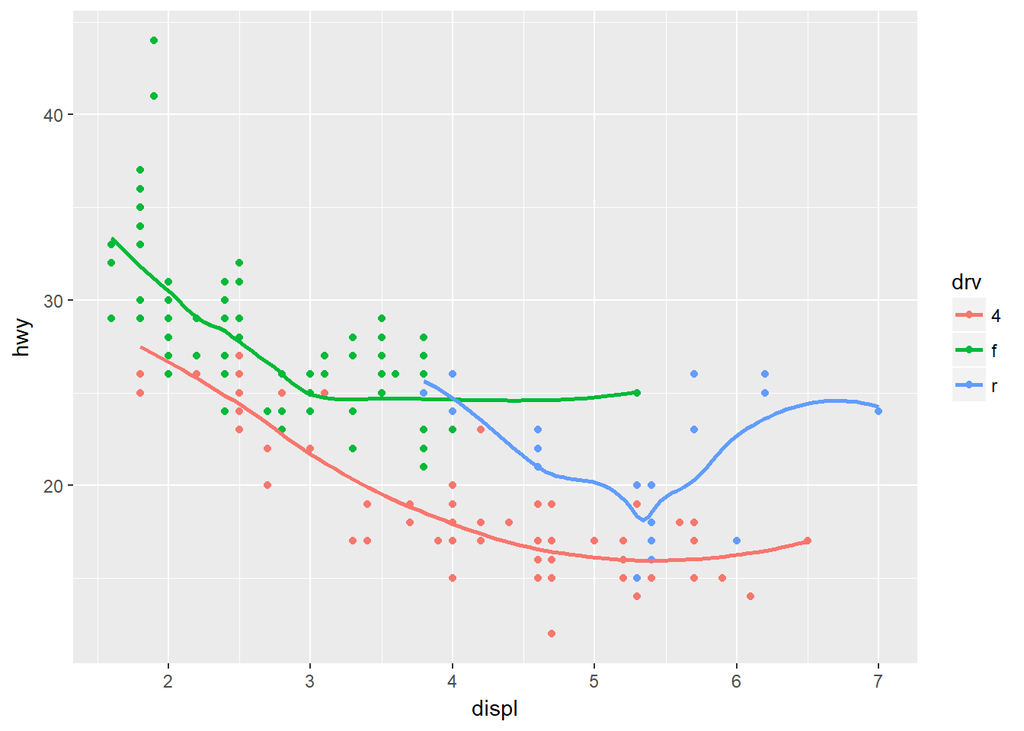

```r
ggplot(data = mpg, mapping = aes(x = displ, y = hwy, color = drv)) +
  geom_point() +
  geom_smooth(se = FALSE)
```

### 3. What does `show.legend = FALSE` do? What happens if you remove it? Why do you think I used it earlier in the chapter?

`show.legend = FALSE` removes the graph’s legend, which tells what each of the group aesthetics represents. When you remove `show.legend=FALSE`, the legend appears by default if the graph uses aesthetics by group. It was used earlier in the chapter in an example including 3 graphs, not all of which were grouped by an aesthetic, and this was done in order to make all graphs in the example consistent.

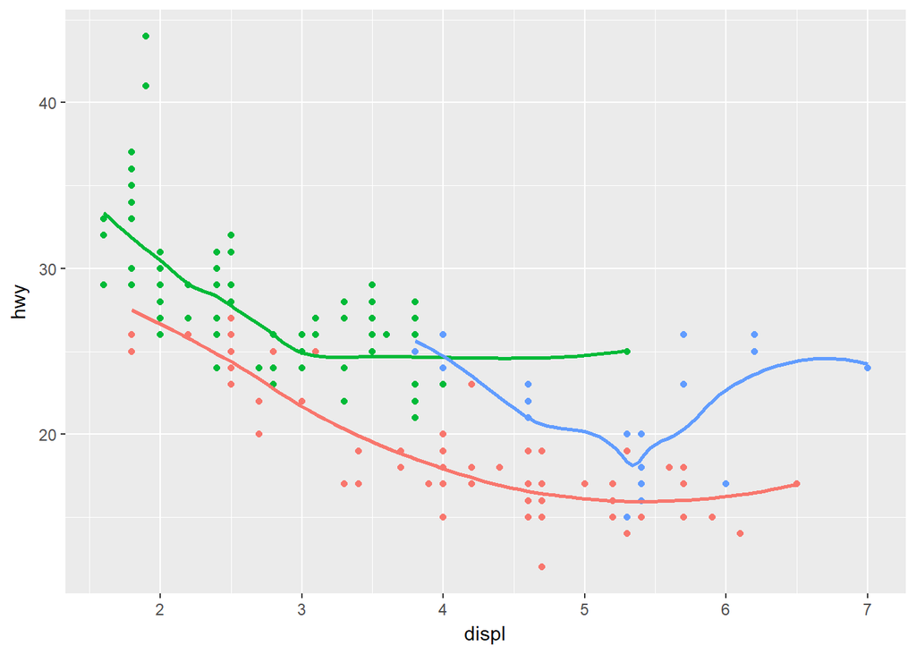

```r
ggplot(data = mpg, mapping = aes(x = displ, y = hwy, color = drv)) +
  geom_point(show.legend = FALSE) +
  geom_smooth(se = FALSE, show.legend = FALSE)
```

### 4. What does the `se` argument to `geom_smooth()` do?

The `se` argument to `geom_smooth()` specifies whether or not to include a representation of the confidence interval around the line in the graph.

### 5. Will these two graphs look different? Why/why not?

The two graphs will not look different, because specifying mappings in the overall `ggplot()` function will define them as global mappings that will be passed to each of the geoms that are added to the graph.

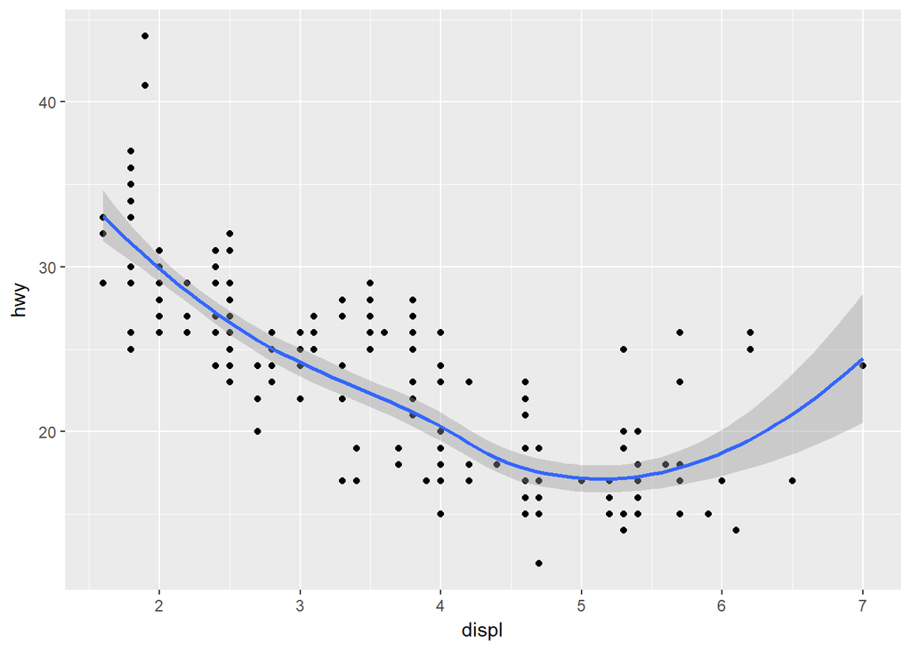

```r
ggplot(data = mpg, mapping = aes(x = displ, y = hwy)) +
  geom_point() +
  geom_smooth()
```

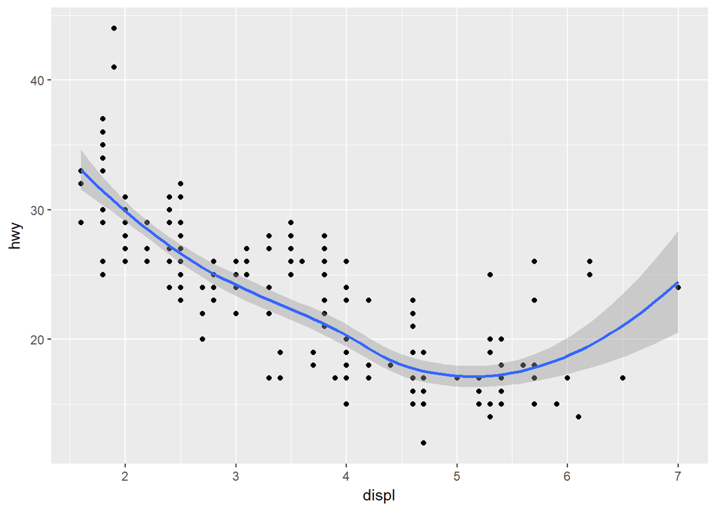

```r
ggplot() +
  geom_point(data = mpg, mapping = aes(x = displ, y = hwy)) +
  geom_smooth(data = mpg, mapping = aes(x = displ, y = hwy))
```

### 6. Recreate the R code necessary to generate the following graphs.

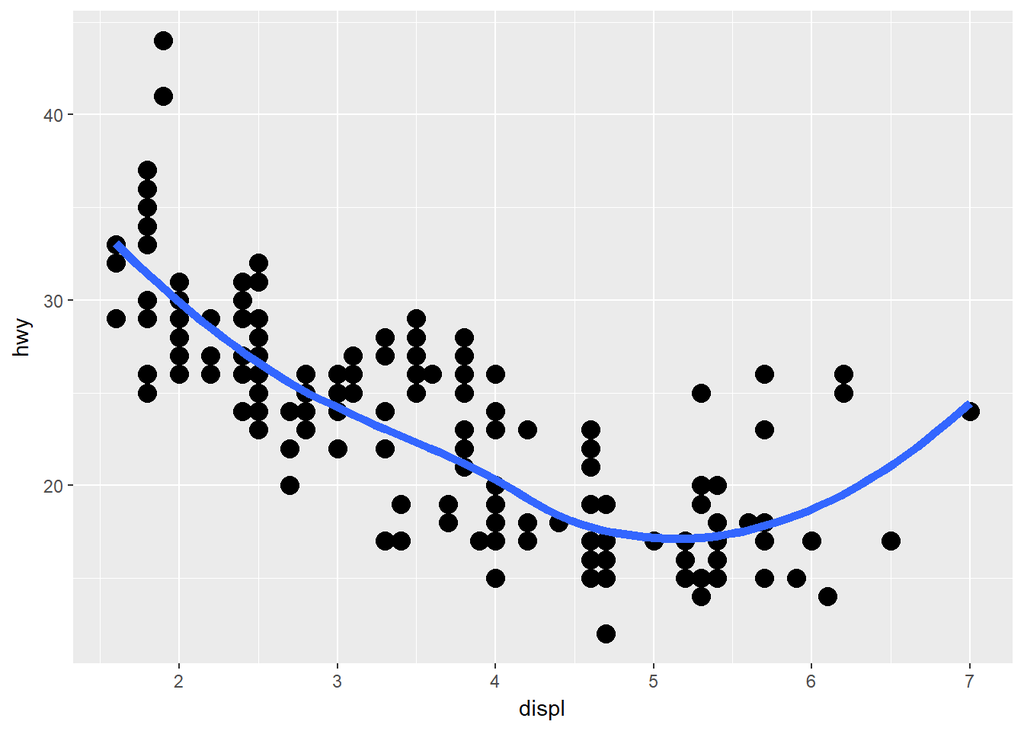

```r
ggplot(data = mpg, mapping = aes(x = displ, y = hwy)) +
  geom_point(color="black", size=4) +
  geom_smooth(se=FALSE, size=2)
```

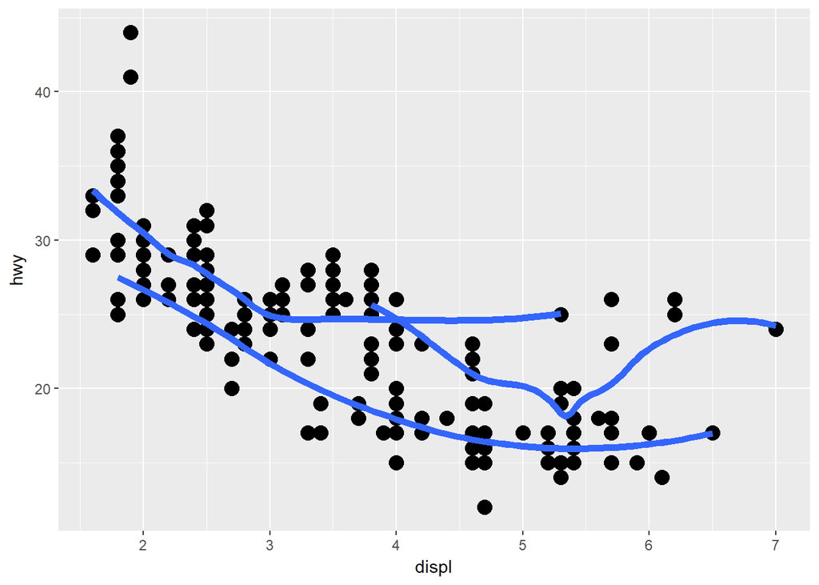

```r
ggplot(data = mpg, mapping = aes(x = displ, y = hwy)) +
  geom_point(color="black", size=4) +
  geom_smooth(mapping=aes(group=drv), se=FALSE, size=2)
```

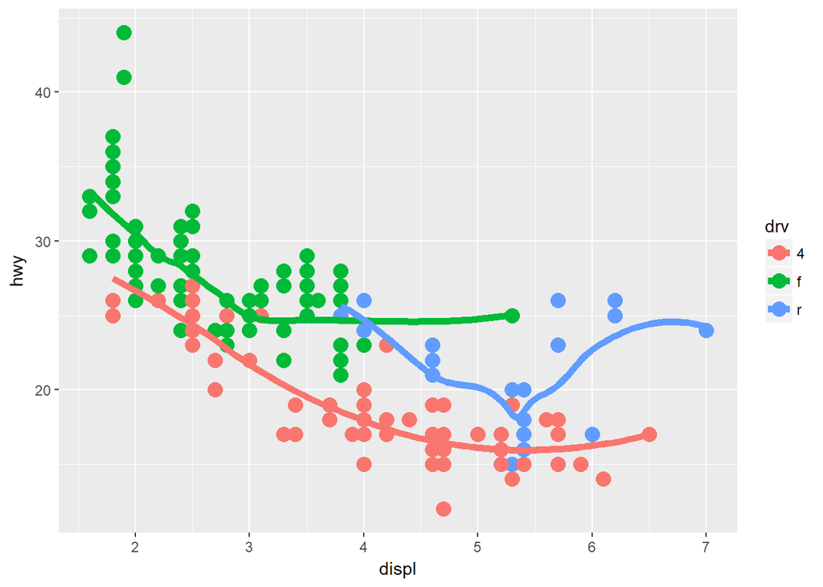

```r
ggplot(data = mpg, mapping = aes(x = displ, y = hwy)) +
  geom_point(mapping=aes(color=drv), size=4) +
  geom_smooth(mapping=aes(color=drv), se=FALSE, size=2)
```

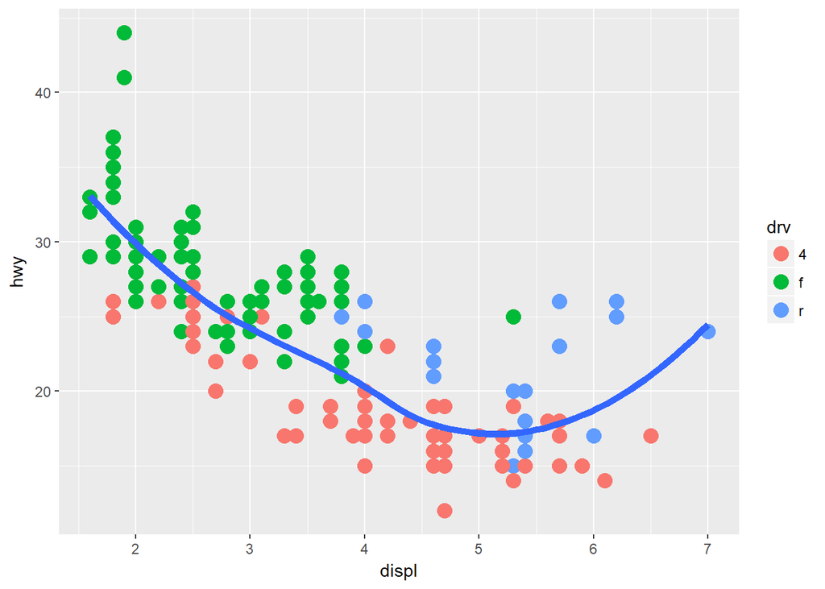

```r
ggplot(data = mpg, mapping = aes(x = displ, y = hwy)) +
  geom_point(mapping=aes(color=drv), size=4) +
  geom_smooth(se=FALSE, size=2)
```

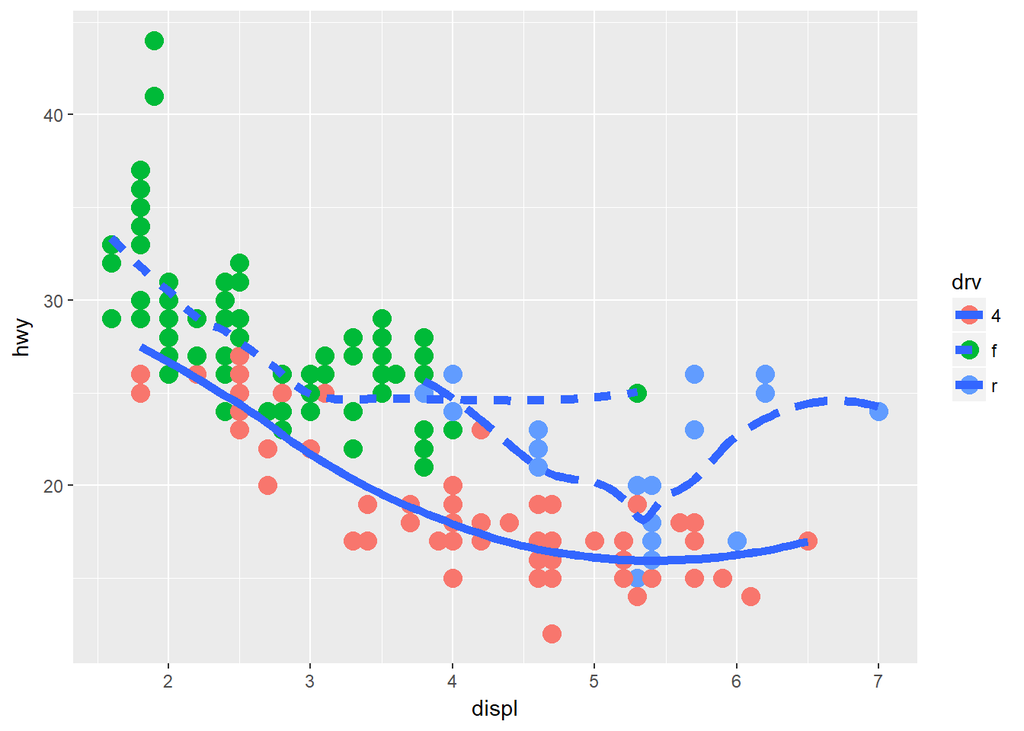

```r
ggplot(data = mpg, mapping = aes(x = displ, y = hwy)) +
  geom_point(mapping=aes(color=drv), size=4) +
  geom_smooth(mapping=aes(linetype=drv), se=FALSE, size=2)
```

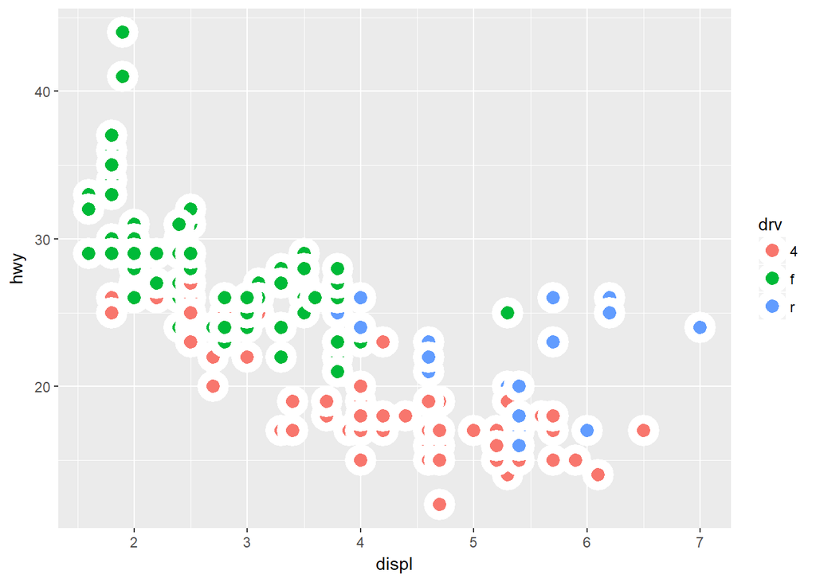

```r
ggplot(data = mpg, mapping = aes(x = displ, y = hwy)) +
  geom_point(mapping=aes(fill=drv), size=4, shape=21, color="white", stroke=4)
```

## Section 3.7.1

### 2. What does `geom_col()` do? How is it different to `geom_bar()`?

`geom_col()` and `geom_bar()` both create bar charts. However, with `geom_col()`, the height of the bars represents the values of the variable defined in aesthetic `y`. Meanwhile, with `geom_bar()` the height of the bars represents the number of cases in each group.

## Answer this question:

### 1. Look at the data graphics at the following link: [What is a Data Scientist](https://static.guim.co.uk/sys-images/Guardian/Pix/pictures/2012/3/2/1330695817953/EMC2-graphic-on-data-scie-008.jpg). Please briefly critique the designer’s choices. What works? What doesn’t work? What would you have done differently?

I think the most effective graphics the designer used were the bar charts (used to compare data scientists to business intelligence professionals), because it’s clear from the differences in the height of the bars that data scientists do differ from business intelligence professionals in the ways that the text points out. The choice of blue and dark gray as the two colors to represent each group is maybe not as effective, since there isn’t much contrast between those colors. There are certain graphics that use size to illustrate differences (the squares representing responses to the question about the best source of new data science talent, and circles representing the fields that data scientists and BI professionals studied). These graphics are somewhat effective in the sense that the viewer can clearly tell which category is the biggest and what the relative size of the other categories is, but their effectiveness was undercut because I was confused about how the percentage mapped to the area of the circles/squares: for example, the 12% square is about a fourth the size of the 24% square (I later realized that the percentages likely map to the height of the squares/circles, not their area.) Still, if viewers are paying attention to area, this representation would exaggerate the differences between the categories. It’s especially confusing for the circles, since it’s harder to compare the heights of the circles.

In general, I would have organized this series of graphics in a more logical manner, so that the graphic as a whole tells a more coherent story. For one thing, there are several graphics that compare data scientists to business intelligence professionals, but they’re scattered throughout, rather than grouped together to provide a clear picture of how data scientists tend to differ from business intelligence professionals. I might have started with the graphics that provide background for who data scientists are and what they do, then included a section comparing data scientists to business intelligence professionals, and then ended with the graphics about the future of the data science workforce.